# Design Document

Alec Buchanan & Jason Lawrence

October 11, 2018

## 1. Program Design

This programming assignment uses programming assignment one as a base. If you would like to see the documentation for the super peer check the documentation for index server in the PA 1 design document.

Two different topologies were implemented. The first topology implemented was the linear topology, and the second one implemented was the broadcast topology. The linear topology was implemented like a library that needs to be imported. On the other hand, the broadcast topology was coded in the superpeer.py file.

### 1.1 Linear Topology

The linear topology works like a ring. Each super peer has a left neighbor and a right neighbor. Messages are sent to the left neighbor and are forwarded around the ring until their time to live expires or they have made a full circle.

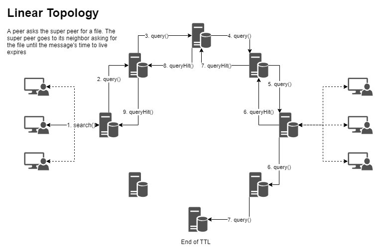

#### 1.1.1 Program Structure

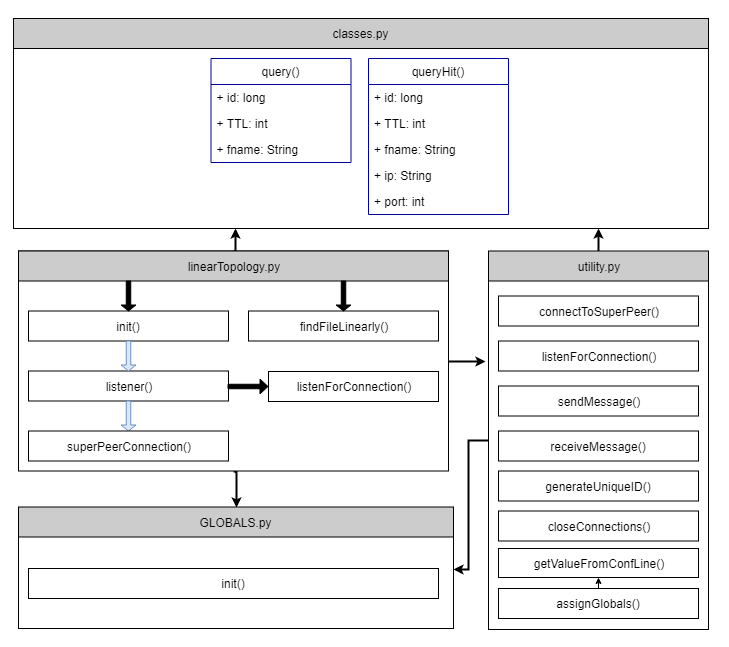

**linearTopology.py**

| Function | Description |
| --- | --- |
| int init ([(char[15],int)] * (char[:])) | The initialization function. It reads the config file, sets globals, and spawns a listener thread. The listener thread listens for incoming connections. |
| int listener ([(char[15],int)] * (char[:])) | Listens for incoming connections. Takes a function as an argument. The argument function should take a file name and search local leafs for files. It should return the hits with a tupple of (ip,port) |
| int findFileLinearly (char[:]) | Initiates linear search for file. Takes file name as argument. |
| int superPeerConnection (socket.socket, [(char[15],int)] * (char[:])) | Handles super peer connection and forwards queries. Takes in a connection object and a function to search for files registered on index server. |

**utility.py**

| Function | Description |
| --- | --- |
| int connectToSuperPeer (char[15],int) | Connects to server at given address |
| generator listenForConnection (int) | Wait for a connection on a given port and yield the socket object when a connection is made. |
| int sendMessage (socket.socket, void *) | sends the given message over the given socket. |
| int receiveMessage (socket.socket) | reads from the receive buffer when a message is received |
| char * getValueFromConfLine (char[:]) | Takes a line from the config file and returns the value from that line |
| void closeConnections (socket.socket, socket.socket) | closes two connections at once |
| void assignGlobals (file) | Takes config file and assigns globals variables based off of file |
| long generateUniqueID () | Creates a unique message ID |

**GLOBALS.py**

| Function | Description |
| --- | --- |
| void init (void) | Defines and initializes global variables |

#### 1.1.2 Thread Timeline

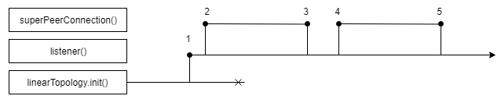

**Events**

1. init is done reading config and setting global variables, so it starts the listener thread.
2. listener receives a connection from another super peer
3. Connection is closed for various reason (error, expired TTL, loop detected)
4. listener receives a connection from another super peer
5. Connection is closed for various reason (error, expired TTL, loop detected)

#### 1.1.3 Protocol

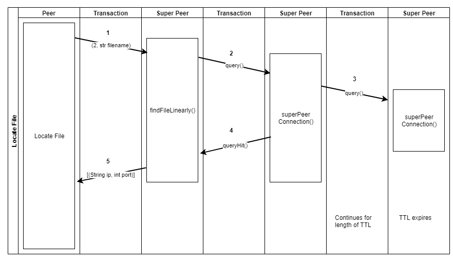

**Transactions**

1. *peer* asks *super peer* to search for file
2. *super peer* sends out a query to its neighboring super peer
3. *super peer* forwards query until TTL expires. The last peer is in charge of closing the connection. The closing connection makes a ripple affect going all the way back to the originating function.
4. *super peer* has a peer with the file, so a queryhit is sent
5. *super peer* sends the peer a list of other peers that have the file

### 1.2 Broadcast Topology

Broadcast topology is pretty self explanatory. When a super peer queries a file, it sends the query to all other super peers at once. The super peers with the file respond with a query hit.

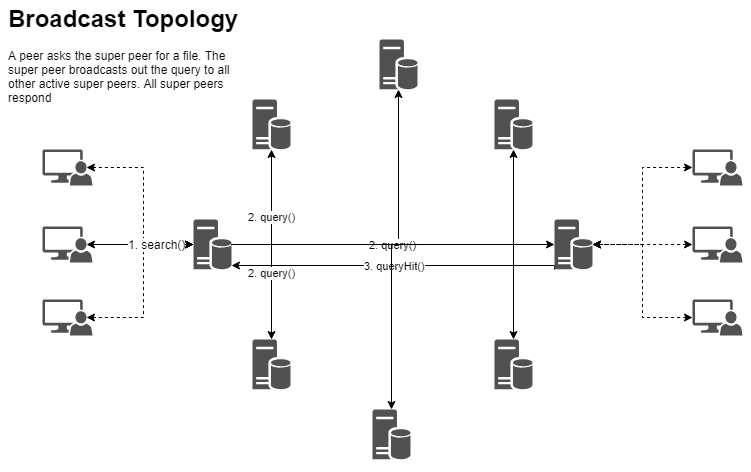

#### 1.2.1 Program Structure

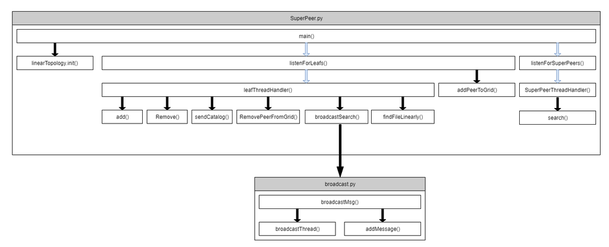

**SuperPeer.py**

[output not shown]

#### 1.2.2 Thread Timeline

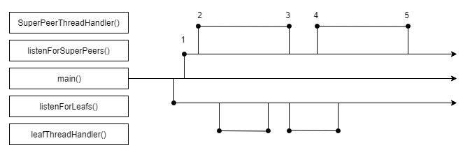

**Events**

1. *main()* spawns thread to listen for super peer connections under the broadcast port
2. *listenForSuperPeers()* gets a connection from another super peer
3. *superPeerThreadHandler()* sees that the connection has been closed
4. *listenForSuperPeers()* gets a connection from another super peer
5. *superPeerThreadHandler()* sees that the connection has been closed

#### 1.2.3 Protocol

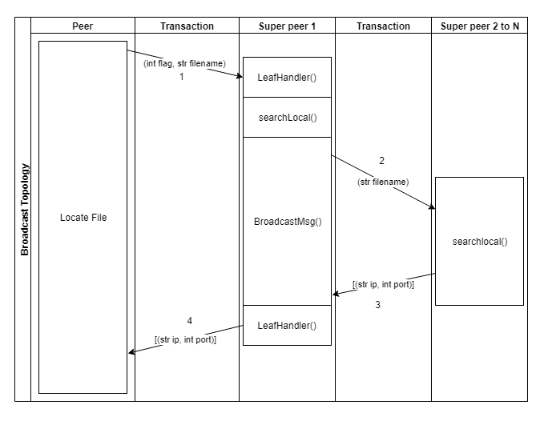

**Transactions**

1. *peer* asks *super peer* to search for file
2. *super peer 1* broad casts out queries to all super peers
3. *super peer i* sends back a queryhit if it has the file registered
4. *super peer 1* responds to the peer with a list of peer servers

## 2. Design Tradeoffs

### 2.2 Implimented

**(Linear topology) Should neighbor connections be kept open or should a new connection be made for every query?**  
We decided that a new connection should be made for every query. Creating and closing sockets is not very resource or time intensive, so there is not much to lose. Also, this method allows for easier multitasking. It is difficult to have multiple threads operate on the same socket. However, it is a lot easier to have multiple threads work on multiple sockets. Whenever a new query or connection comes in, a new thread is spawned.